# Introduction

## Calling the results array of the interpolated pressure at the monitoring points.

```python
timeSteps = pvdfile_elastop_Kd_FM1.timesteps
results = {}
```

```python
results["pressure"] = pvdfile_elastop_Kd_FM1.read_time_series(
    "pressure_interpolated", pts=pressure_points
)
```

## Save the pressure data in a csv file

```python
# Output CSV file
output_csv = "pressure_results.csv"

# Write results to a CSV file
with open(output_csv, mode="w", newline="") as file:
    writer = csv.writer(file)
    node_ids = 3
    # Write header row: "Time" + Node IDs (e.g., pt0, pt1, pt2)
    header = ["Time"] + [
        f"pt{node_id}" for node_id in range(node_ids)
    ]  # Adjust as needed
    writer.writerow(header)

    # Write each row: time step + scaled pressures for each node
    for i, time in enumerate(timeSteps):
        row = [time]
        for node_id in range(node_ids):
            # Scale the pressure value by 1e-6 and append it
            scaled_pressure = results["pressure"][f"pt{node_id}"][i] * 1e-6
            row.append(scaled_pressure)
        writer.writerow(row)
```

## Calling the results array of the mass flow rate at the injection points.

```python
results["MassFlowRate"] = pvdfile_elastop_Kd_FM1.read_time_series(
    "MassFlowRate", pts=flowRate_points
)
```

## Save the mass flow rate data in a csv file

```python
# Output CSV file
output_csv = "MassFlowRate_results.csv"

# Write results to a CSV file
with open(output_csv, mode="w", newline="") as file:
    writer = csv.writer(file)
    node_ids = 12
    # Write header row: "Time" + Node IDs (e.g., pt0 ~ pt11)
    header = ["Time"] + [
        f"pt{node_id}" for node_id in range(node_ids)
    ]  # Adjust as needed
    writer.writerow(header)

    # Write each row: time step + scaled pressures for each node
    for i, time in enumerate(timeSteps):
        row = [time]
        for node_id in range(node_ids):
            # Scale the pressure value by 1e-6 and append it
            scaled_pressure = results["MassFlowRate"][f"pt{node_id}"][i]
            row.append(scaled_pressure)
        writer.writerow(row)
```

## Calling the results array of the displacements at the anchors.

```python
results["displacement"] = pvdfile_elastop_Kd_FM1.read_time_series(
    "displacement", pts=displacement_points
)
```

## Save the displacement data in a csv file

```python
# Output CSV file
output_csv = "displacement_results.csv"

# Write results to a CSV file
with open(output_csv, mode="w", newline="") as file:
    writer = csv.writer(file)
    node_ids = 10  # Number of nodes (pt0 ~ pt9)

    # Write header row: "Time" + Displacement Components (e.g., pt0_ux, pt0_uy, pt0_uz)
    header = ["Time"]
    for node_id in range(node_ids):
        header.extend([f"pt{node_id}_ux", f"pt{node_id}_uy", f"pt{node_id}_uz"])
    writer.writerow(header)

    # Write each row: time step + displacement components for each node
    for i, time in enumerate(timeSteps):
        row = [time]
        for node_id in range(node_ids):
            # Extract the displacement vector for the node and split into components
            displacement_vector = results["displacement"][f"pt{node_id}"][i]
            ux, uy, uz = (
                displacement_vector[0],
                displacement_vector[1],
                displacement_vector[2],
            )
            row.extend([ux, uy, uz])
        writer.writerow(row)
```

```python
results["stress"] = pvdfile_elastop_Kd_FM1.read_time_series("sigma", pts=stress_points)
```

```python
# Output CSV file
output_csv = "stress_results.csv"

# Write results to a CSV file
with open(output_csv, mode="w", newline="") as file:
    writer = csv.writer(file)
    node_ids = 5  # Number of nodes (pt0 ~ pt9)

    # Write header row: "Time" + Displacement Components (e.g., pt0_ux, pt0_uy, pt0_uz)
    header = ["Time"]
    for node_id in range(node_ids):
        header.extend([f"pt{node_id}_sigxx", f"pt{node_id}_sigyy", f"pt{node_id}_sigzz", f"pt{node_id}_sigxy", f"pt{node_id}_sigyz", f"pt{node_id}_sigxz"])
    writer.writerow(header)

    # Write each row: time step + displacement components for each node
    for i, time in enumerate(timeSteps):
        row = [time]
        for node_id in range(node_ids):
            # Extract the displacement vector for the node and split into components
            stress_tensor = results["stress"][f"pt{node_id}"][i]
            sig_xx, sig_yy, sig_zz, sig_xy, sig_yz, sig_xz = (
                stress_tensor[0],
                stress_tensor[1],
                stress_tensor[2],
                stress_tensor[3],
                stress_tensor[4],
                stress_tensor[5]
            )
            row.extend([sig_xx, sig_yy, sig_zz, sig_xy, sig_yz, sig_xz])
        writer.writerow(row)
```

## Pressure at P3: $(0, -0.63, -1.36)$

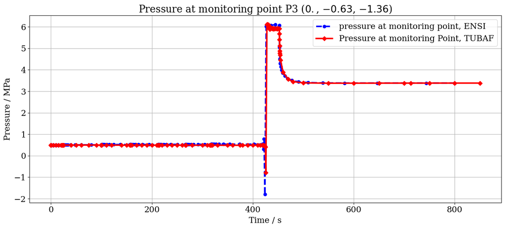

```python
fig, ax = plt.subplots(figsize=(14, 6.5))
# Read the CSV file
csv_file = "pressure_results.csv"
pressureData = pd.read_csv(csv_file)
ax.plot(
    FM1[1],
    FM1[4] * 1e-6,
    label="pressure at monitoring point, ENSI",
    color="blue",
    ls="--",
    marker="o",
)
ax.plot(
    pressureData["Time"],
    pressureData["pt1"],
    # instead the following two lines are used to plot the results
    # timeSteps,
    # results["pressure"]["pt1"] * 1e-6,
    label="Pressure at monitoring Point, TUBAF",
    color="red",
    ls="-",
    marker="D",
)
ax.set_title("Pressure at monitoring point P3 ($0.$, $-0.63$, $-1.36$)")
ax.set_xlabel("Time / s")
ax.set_ylabel("Pressure / MPa")
ax.legend()
ax.grid(True)
fig.tight_layout()
```

## Pressure at P2: $(-1.5, 0, 0)$

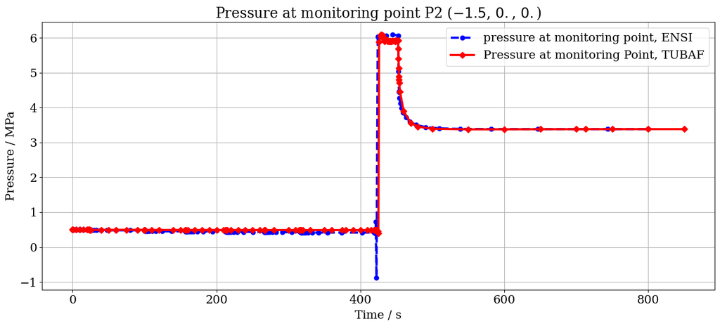

```python
fig, ax = plt.subplots(figsize=(14, 6.5))
# Read the CSV file
csv_file = "pressure_results.csv"
pressureData = pd.read_csv(csv_file)
ax.plot(
    FM1[1],
    FM1[3] * 1e-6,
    label="pressure at monitoring point, ENSI",
    color="blue",
    ls="--",
    marker="o",
)
ax.plot(
    pressureData["Time"],
    pressureData["pt2"],
    # instead the following two lines are used to plot the results
    # timeSteps,
    # results["pressure"]["pt1"] * 1e-6,
    label="Pressure at monitoring Point, TUBAF",
    color="red",
    ls="-",
    marker="D",
)
ax.set_title("Pressure at monitoring point P2 ($-1.5$, $0.$, $0.$)")
ax.set_xlabel("Time / s")
ax.set_ylabel("Pressure / MPa")
ax.legend()
ax.grid(True)
fig.tight_layout()
```

## Pressure along fault dip at $t= 317$

```python
start_point_left = (5.32527, 0.0, 0.0)
end_point_left = (14.6514, 20.0, 0.0)

start_point_right = (5.34857, 0.0, 0.0)
end_point_right = (14.6747, 20.0, 0.0)

start_point_mid = (
    start_point_left[0] + (start_point_right[0] - start_point_left[0]) / 2.0,
    0.0, 0.0
)
end_point_mid = (
    end_point_left[0] + (end_point_right[0] - end_point_left[0]) / 2.0,
    20.0, 0.0
)

stop = np.sqrt(
    (end_point_mid[0] - start_point_mid[0]) ** 2.0
    + (end_point_mid[1] - start_point_mid[1]) ** 2.0
)


def divide_line(start_point, end_point, n):
    fault_axis = []
    for i in range(0, n + 1):
        x = start_point[0] + (end_point[0] - start_point[0]) * i / n
        y = start_point[1] + (end_point[1] - start_point[1]) * i / n
        fault_axis.append([x, y, 0.0])
    return fault_axis


npts = 1000
fpoints_mid = divide_line(start_point_mid, end_point_mid, npts)
fpoints_left = divide_line(start_point_left, end_point_left, npts)
fpoints_right = divide_line(start_point_right, end_point_right, npts)
rad = np.linspace(start=0, stop=stop, num=npts + 1)
```

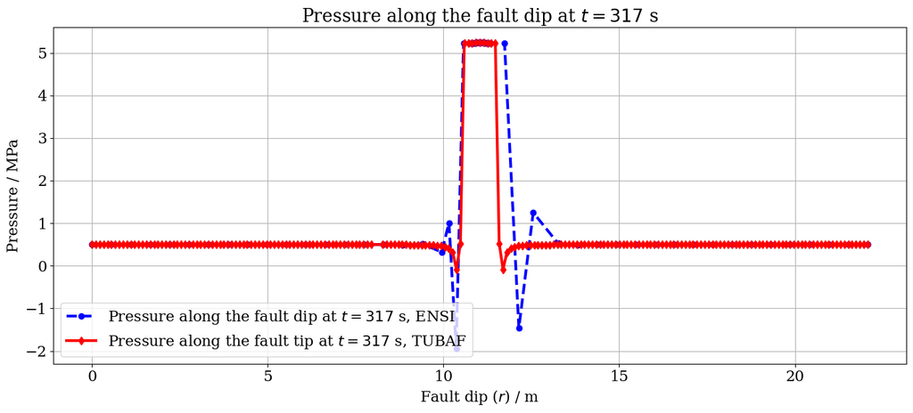

```python
import matplotlib.pyplot as plt

# Create the plot figure and axis
fig, ax = plt.subplots(figsize=(14, 6.5))

# Plot the first dataset (ENSI pressure along the fault dip) after filtering out zeros
nonzero_indices_1 = profiles_along_fault_dip[1] != 0  # Find non-zero indices
ax.plot(
    profiles_along_fault_dip[0][nonzero_indices_1],  # Filter x-values
    profiles_along_fault_dip[1][nonzero_indices_1]
    * 1e-6,  # Filter y-values and convert to MPa
    label="Pressure along the fault dip at $t=317$ s, ENSI",
    color="blue",
    ls="--",
    marker="o",
)

# Define the time for the second dataset
itime = 317

# Plot the second dataset (TUBAF pressure along the fault tip) after filtering out zeros
rad_data = rad[::5]
pressure_data = (
    pvdfile_elastop_Kd_FM1.read_set_data(
        itime, "pressure_interpolated", pointsetarray=fpoints_mid
    )[::5]
    * 1e-6
)
nonzero_indices_2 = pressure_data != 0  # Find non-zero indices
ax.plot(
    rad_data[nonzero_indices_2],  # Filter x-values
    pressure_data[nonzero_indices_2],  # Filter y-values
    label=f"Pressure along the fault tip at $t = {itime}$ s, TUBAF",
    color="red",
    ls="-",
    marker="d",
)

# Set plot title and axis labels
ax.set_title("Pressure along the fault dip at $t=317$ s")
ax.set_xlabel("Fault dip ($r$) / m")
ax.set_ylabel("Pressure / MPa")

# Add legend and grid
ax.legend()
ax.grid(True)

# Adjust layout
fig.tight_layout()

# Show the plot
plt.show()
```

## Injection Rate

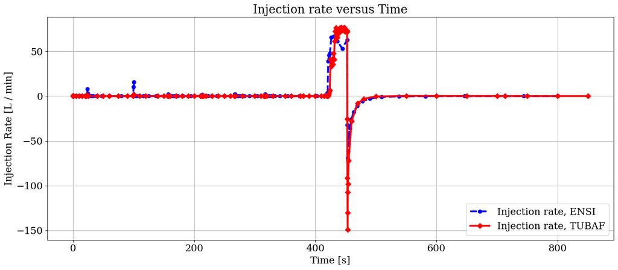

```python
fig, ax = plt.subplots(figsize=(14.5, 6.5))
# Read the CSV file
csv_file = "MassFlowRate_results.csv"
MassFlowRateData = pd.read_csv(csv_file)
ax.plot(
    FM1[1],
    FM1[2],
    label="Injection rate, ENSI",
    color="blue",
    ls="--",
    marker="o",
)

# Initialize the total mass flow rate
total_mass_flow_rate = 0

# Loop through keys pt0 to pt11 and sum the values
for i in range(12):  # From pt0 to pt11
    key = f"pt{i}"
    total_mass_flow_rate += results["MassFlowRate"][key] * 60.0 * 2.0

MassFlowRateData["TotalMassFlowRate"] = (
    MassFlowRateData.iloc[:, 1:].sum(axis=1) * 60.0 * 2.0
)  # Sum across all columns except "Time"

ax.plot(
    MassFlowRateData["Time"],
    MassFlowRateData["TotalMassFlowRate"],
    # timeSteps,
    # total_mass_flow_rate,
    label="Injection rate, TUBAF",
    color="red",
    ls="-",
    marker="D",
)

ax.set_title("Injection rate versus Time")
ax.set_xlabel("Time [s]")
ax.set_ylabel("Injection Rate [L / min]")
ax.legend(loc="lower right")
ax.grid(True)
fig.tight_layout()
```

## Differential displacements between anchors

```
(0.0, 800.0)
```

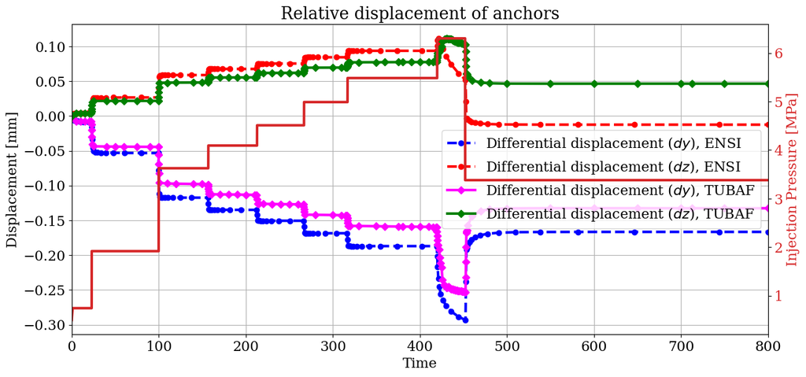

```python
fig, ax1 = plt.subplots(figsize=(14.5, 6.5))
csv_file = "displacement_results.csv"
displacementData = pd.read_csv(csv_file)
ax1.plot(
    FM1[1],
    FM1[6] * 1000.0,
    label="Differential displacement ($dy$), ENSI",
    color="blue",
    ls="--",
    marker="o",
)  # Line plot with markers
ax1.plot(
    FM1[1],
    FM1[7] * 1000.0,
    label="Differential displacement ($dz$), ENSI",
    color="red",
    ls="--",
    marker="o",
)
# Line plot with markers

ax1.plot(
    displacementData["Time"],
    (displacementData["pt0_ux"] - displacementData["pt1_ux"]) * 1e3,
    # timeSteps,
    # (results["displacement"]["pt0"].T[0]
    # - results["displacement"]["pt1"].T[0]) * 1e3,
    label="Differential displacement ($dy$), TUBAF",
    color="magenta",
    ls="-",
    marker="D",
)
ax1.plot(
    displacementData["Time"],
    (displacementData["pt0_uy"] - displacementData["pt1_uy"]) * 1e3,
    # timeSteps,
    # (results["displacement"]["pt0"].T[1]
    # - results["displacement"]["pt1"].T[1]) * 1e3,
    label="Differential displacement ($dz$), TUBAF",
    color="green",
    ls="-",
    marker="D",
)

ax1.set_title("Relative displacement of anchors")
ax1.set_xlabel("Time")
ax1.set_ylabel("Displacement [mm]")
ax1.legend()
ax1.grid(True)

# Create a second y-axis for the second data series
ax2 = ax1.twinx()
color = "tab:red"
ax2.set_ylabel("Injection Pressure [MPa]", color=color)  # For the second data series
ax2.plot(injectionPressure[0], injectionPressure[4] / 1e6, color=color)
ax2.tick_params(axis="y", labelcolor=color)
ax2.set_xlim([0, 800])
# Set x-axis limits
```

## Rotation matrix with respect to the fault dip angle

```python
theta = 155
rotation_matrix = np.array(
    [
        [math.cos(math.radians(theta)), math.sin(math.radians(theta))],
        [-math.sin(math.radians(theta)), math.cos(math.radians(theta))],
    ]
)
print(rotation_matrix)
```

```
[[-0.90630779  0.42261826]
 [-0.42261826 -0.90630779]]
```

## Calculation of the normal and shear displacment along the fault dip

```python
def displacement_ns(file, theta, pt_left, pt_right):
    u_nd_left = (
        file["displacement"][pt_left].T[0] * math.cos(math.radians(theta))
        + file["displacement"][pt_left].T[1] * math.sin(math.radians(theta))
    )
    u_sd_left = -file["displacement"][pt_left].T[0] * math.sin(
        math.radians(theta)
    ) + file["displacement"][pt_left].T[1] * math.cos(math.radians(theta))
    ##
    u_nd_right = file["displacement"][pt_right].T[0] * math.cos(
        math.radians(theta)
    ) + file["displacement"][pt_right].T[1] * math.sin(math.radians(theta))
    u_sd_right = -file["displacement"][pt_right].T[0] * math.sin(
        math.radians(theta)
    ) + file["displacement"][pt_right].T[1] * math.cos(math.radians(theta))
    return abs(u_nd_left) + abs(u_nd_right), abs(u_sd_left) + abs(u_sd_right)
```

```python
u_nd, u_sd = displacement_ns(results, 155, "pt2", "pt3")
```

## Fault displacement at P1: $(0, 0, 0)$

```
(0.0, 800.0)
```

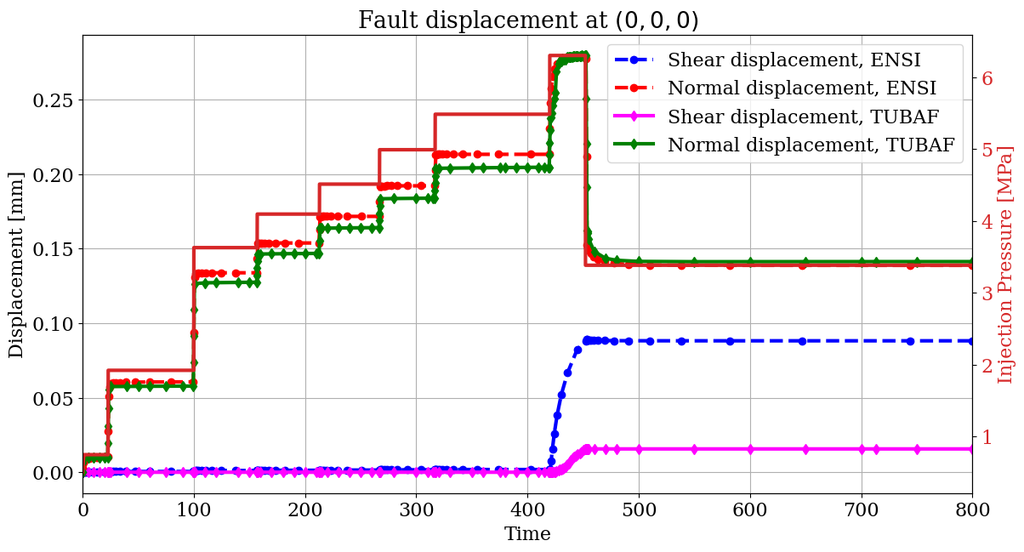

```python
fig, ax1 = plt.subplots(figsize=(13.5, 7))
ax1.plot(
    FM1[1],
    FM1[8] * 1000.0,
    label="Shear displacement, ENSI",
    color="blue",
    ls="--",
    marker="o",
)  # Line plot with markers
ax1.plot(
    FM1[1],
    FM1[10] * 1000.0,
    label="Normal displacement, ENSI",
    color="red",
    ls="--",
    marker="o",
)  # Line plot with markers
ax1.plot(
    timeSteps,
    u_sd * 1000.0,
    label="Shear displacement, TUBAF",
    color="magenta",
    ls="-",
    marker="d",
)
ax1.plot(
    timeSteps,
    u_nd * 1000.0,
    label="Normal displacement, TUBAF",
    color="green",
    ls="-",
    marker="d",
)
ax1.set_title("Fault displacement at $(0, 0, 0)$")
ax1.set_xlabel("Time")
ax1.set_ylabel("Displacement [mm]")
ax1.legend()
ax1.grid(True)

# Create a second y-axis for the second data series
ax2 = ax1.twinx()
color = "tab:red"
ax2.set_ylabel("Injection Pressure [MPa]", color=color)  # For the second data series
ax2.plot(injectionPressure[0], injectionPressure[4] / 1e6, color=color)
ax2.tick_params(axis="y", labelcolor=color)
ax2.set_xlim([0, 800])
# Set x-axis limits
```

```python
u_nd, u_sd = displacement_ns(results, 155, "pt4", "pt5")
```

## Fault displacement at P3: $(0., -0.63, -1.36)$

```
(0.0, 800.0)
```

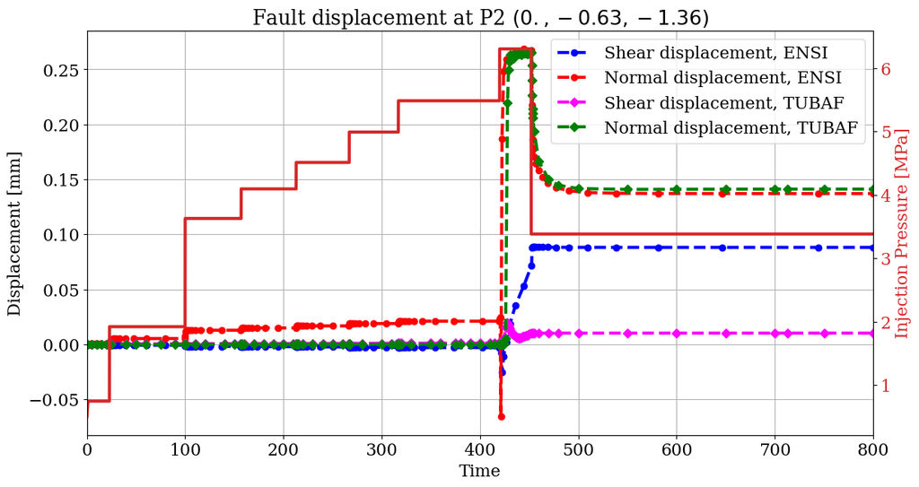

```python
fig, ax1 = plt.subplots(figsize=(13.5, 7))
ax1.plot(
    FM1[1],
    FM1[14] * 1000.0,
    label="Shear displacement, ENSI",
    color="blue",
    ls="--",
    marker="o",
)
ax1.plot(
    FM1[1],
    FM1[16] * 1000.0,
    label="Normal displacement, ENSI",
    color="red",
    ls="--",
    marker="o",
)
ax1.plot(
    timeSteps,
    u_sd * 1000.0,
    label="Shear displacement, TUBAF",
    color="magenta",
    ls="--",
    marker="D",
)
ax1.plot(
    timeSteps,
    u_nd * 1000.0,
    label="Normal displacement, TUBAF",
    color="green",
    ls="--",
    marker="D",
)
ax1.set_title("Fault displacement at P2 $(0., -0.63, -1.36)$")
ax1.set_xlabel("Time")
ax1.set_ylabel("Displacement [mm]")
ax1.legend()
ax1.grid(True)

# Create a second y-axis for the second data series
ax2 = ax1.twinx()
color = "tab:red"
ax2.set_ylabel("Injection Pressure [MPa]", color=color)  # For the second data series
ax2.plot(injectionPressure[0], injectionPressure[4] / 1e6, color=color)
ax2.tick_params(axis="y", labelcolor=color)
ax2.set_xlim([0, 800])
# Set x-axis limits
```

```python
u_nd, u_sd = displacement_ns(results, 155, "pt6", "pt7")
```

```
(0.0, 800.0)
```

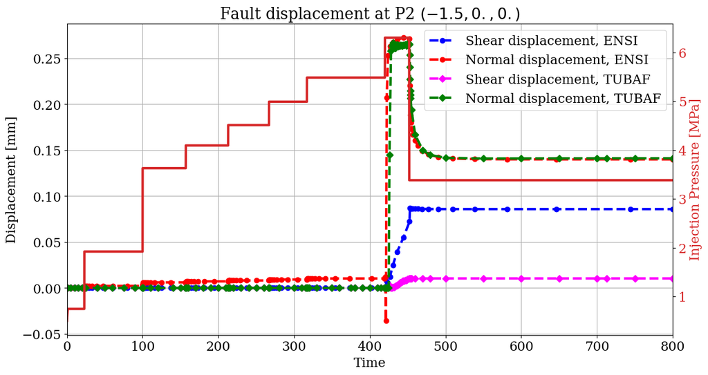

```python
fig, ax1 = plt.subplots(figsize=(13.5, 7))
ax1.plot(
    FM1[1],
    FM1[11] * 1000.0,
    label="Shear displacement, ENSI",
    color="blue",
    ls="--",
    marker="o",
)
ax1.plot(
    FM1[1],
    FM1[13] * 1000.0,
    label="Normal displacement, ENSI",
    color="red",
    ls="--",
    marker="o",
)
ax1.plot(
    timeSteps,
    u_sd * 1000.0,
    label="Shear displacement, TUBAF",
    color="magenta",
    ls="--",
    marker="D",
)
ax1.plot(
    timeSteps,
    u_nd * 1000.0,
    label="Normal displacement, TUBAF",
    color="green",
    ls="--",
    marker="D",
)
ax1.set_title("Fault displacement at P2 $(-1.5, 0., 0.)$")
ax1.set_xlabel("Time")
ax1.set_ylabel("Displacement [mm]")
ax1.legend()
ax1.grid(True)

# Create a second y-axis for the second data series
ax2 = ax1.twinx()
color = "tab:red"
ax2.set_ylabel("Injection Pressure [MPa]", color=color)  # For the second data series
ax2.plot(injectionPressure[0], injectionPressure[4] / 1e6, color=color)
ax2.tick_params(axis="y", labelcolor=color)
ax2.set_xlim([0, 800])
# Set x-axis limits
```

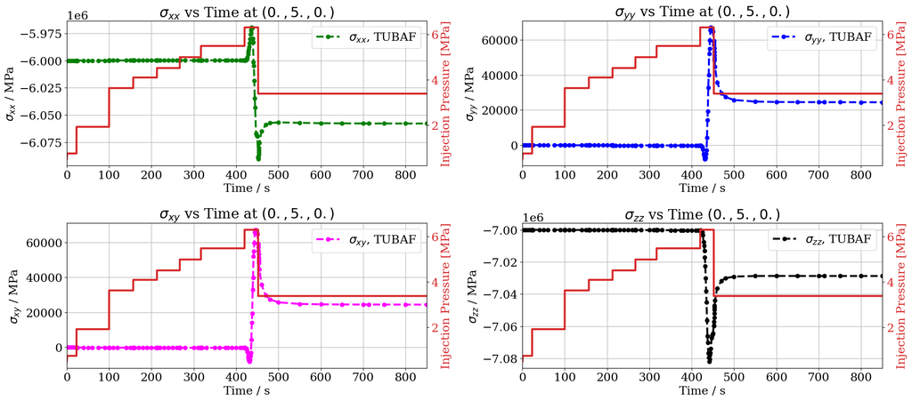

```python
fig, ax1 = plt.subplots(2, 2, figsize=(20, 9))
csv_file = "stress_results.csv"
stressData = pd.read_csv(csv_file)
# Top-left plot
ax1[0, 0].plot(
    stressData["Time"],
    stressData["pt3_sigxx"],
    #timeSteps,
    #results["stress"]["pt3"].T[0] * 1e-6,
    label="$\\sigma_{xx}$, TUBAF",
    color="green",
    ls="--",
    marker="o",
)
ax1[0, 0].set_title("$\\sigma_{xx}$ vs Time at $(0., 5., 0.)$")
ax1[0, 0].set_xlabel("Time / s")
ax1[0, 0].set_ylabel("$\\sigma_{xx}$ / MPa")
ax1[0, 0].legend()
ax1[0, 0].grid(True)

# Create a second y-axis for the second data series
ax2_00 = ax1[0, 0].twinx()
color = "tab:red"
ax2_00.set_ylabel("Injection Pressure [MPa]", color=color)  # For the second data series
ax2_00.plot(injectionPressure[0], injectionPressure[4] / 1e6, color=color)
ax2_00.tick_params(axis="y", labelcolor=color)
ax2_00.set_xlim([0, 850])

# Top-right plot
ax1[0, 1].plot(
    stressData["Time"],
    stressData["pt3_sigxy"],
    #timeSteps,
    #results["stress"]["pt3"].T[1] * 1e-6,
    label="$\\sigma_{yy}$, TUBAF",
    color="blue",
    ls="--",
    marker="o",
)
ax1[0, 1].set_title("$\\sigma_{yy}$ vs Time at $(0., 5., 0.)$")
ax1[0, 1].set_xlabel("Time / s")
ax1[0, 1].set_ylabel("$\\sigma_{yy}$ / MPa")
ax1[0, 1].legend()
ax1[0, 1].grid(True)
# Create a second y-axis for the second data series
ax2_01 = ax1[0, 1].twinx()
color = "tab:red"
ax2_01.set_ylabel("Injection Pressure [MPa]", color=color)  # For the second data series
ax2_01.plot(injectionPressure[0], injectionPressure[4] / 1e6, color=color)
ax2_01.tick_params(axis="y", labelcolor=color)
ax2_01.set_xlim([0, 850])

# Bottom-right plot
ax1[1, 1].plot(
    stressData["Time"],
    stressData["pt3_sigyy"],
    #timeSteps,
    #results["stress"]["pt3"].T[2] * 1e-6,
    label="$\\sigma_{zz}$, TUBAF",
    color="black",
    ls="--",
    marker="o",
)
ax1[1, 1].set_title("$\\sigma_{zz}$ vs Time $(0., 5., 0.)$")
ax1[1, 1].set_xlabel("Time / s")
ax1[1, 1].set_ylabel("$\\sigma_{zz}$ / MPa")
ax1[1, 1].legend()
ax1[1, 1].grid(True)

# Create a second y-axis for the second data series
ax2_11 = ax1[1, 1].twinx()
color = "tab:red"
ax2_11.set_ylabel("Injection Pressure [MPa]", color=color)  # For the second data series
ax2_11.plot(injectionPressure[0], injectionPressure[4] / 1e6, color=color)
ax2_11.tick_params(axis="y", labelcolor=color)
ax2_11.set_xlim([0, 850])

# Bottom-left plot
ax1[1, 0].plot(
    stressData["Time"],
    stressData["pt3_sigxy"],
    #timeSteps,
    #results["stress"]["pt3"].T[3] * 1e-6,
    label="$\\sigma_{xy}$, TUBAF",
    color="magenta",
    ls="--",
    marker="o",
)
ax1[1, 0].set_title("$\\sigma_{xy}$ vs Time at $(0., 5., 0.)$")
ax1[1, 0].set_xlabel("Time / s")
ax1[1, 0].set_ylabel("$\\sigma_{xy}$ / MPa")
ax1[1, 0].legend()
ax1[1, 0].grid(True)

# Create a second y-axis for the second data series
ax2_10 = ax1[1, 0].twinx()
color = "tab:red"
ax2_10.set_ylabel("Injection Pressure [MPa]", color=color)  # For the second data series
ax2_10.plot(injectionPressure[0], injectionPressure[4] / 1e6, color=color)
ax2_10.tick_params(axis="y", labelcolor=color)
ax2_10.set_xlim([0, 850])

# Adjust layout
plt.tight_layout()
plt.show()
```

## Calculation of the shear and normal stresses on the fault dip

```python
def stress_ns(csv_file, file, pt, theta):
    stressData = pd.read_csv(csv_file)
    nVector = np.array(
        [math.cos(math.radians(theta)), math.sin(math.radians(theta)), 0.0]
    )
    # Compute the dyadic product
    dyadic_product_of_the_normal_vector = np.outer(nVector, nVector)
    ndyn_wp = dyadic_product_of_the_normal_vector
    stress_ten = np.zeros((3, 3))
    sigma_wp = np.array([0.0])
    tau_wp = np.array([0.0])
    sig00 = np.array([0.0])
    sig11 = np.array([0.0])
    sig22 = np.array([0.0])
    sig01 = np.array([0.0])
    sig02 = np.array([0.0])
    sig12 = np.array([0.0])
    stress = file[pt]
    for i in range(len(stress)):
        stress_ten[0, 0] = stressData[f"{pt}_sigxx"][i]
        stress_ten[1, 1] = stressData[f"{pt}_sigyy"][i]
        stress_ten[2, 2] = stressData[f"{pt}_sigzz"][i]
        stress_ten[0, 1] = stressData[f"{pt}_sigxy"][i]
        stress_ten[1, 2] = stressData[f"{pt}_sigyz"][i]
        stress_ten[0, 2] = stressData[f"{pt}_sigxz"][i]
        stress_ten[1, 0] = stressData[f"{pt}_sigxy"][i]
        stress_ten[2, 1] = stressData[f"{pt}_sigyz"][i]
        stress_ten[2, 0] = stressData[f"{pt}_sigxz"][i]
        #stress_ten[0, 0] = np.array(stress)[i].T[0]
        #stress_ten[1, 1] = np.array(stress)[i].T[1]
        #stress_ten[2, 2] = np.array(stress)[i].T[2]
        #stress_ten[0, 1] = np.array(stress)[i].T[3]
        #stress_ten[0, 2] = np.array(stress)[i].T[5]
        #stress_ten[1, 2] = np.array(stress)[i].T[4]
        #stress_ten[1, 0] = np.array(stress)[i].T[3]
        #stress_ten[2, 0] = np.array(stress)[i].T[5]
        #stress_ten[2, 1] = np.array(stress)[i].T[4]
        #####
        s_wp = np.tensordot(stress_ten, ndyn_wp)
        t_wp = np.sqrt(
            np.tensordot((np.dot(stress_ten, stress_ten.transpose())), ndyn_wp)
            - s_wp * s_wp
        )
        sigma_wp = np.append(sigma_wp, s_wp)
        tau_wp = np.append(tau_wp, t_wp)
        sig01 = np.append(sig01, stress_ten[0,1])
        sig02 = np.append(sig02, stress_ten[0,2])
        sig12 = np.append(sig12, stress_ten[1,2])
        sig00 = np.append(sig00, stress_ten[0,0])
        sig11 = np.append(sig11, stress_ten[1,1])
        sig22 = np.append(sig22, stress_ten[2,2])
    return sig01, sig02, sig12, sig00, sig11, sig22, sigma_wp, tau_wp
```

## Fault stress at P1: $(0, 0, 0)$

```python
theta = 155.0
pt = "pt0"
csv_file = "stress_results.csv"
file = results["stress"]
sig01, sig02, sig12, sig00, sig11, sig22, sigma_wp, tau_wp = stress_ns(csv_file, file, pt, theta)
```

[output not shown]

```
(0.0, 800.0)
```

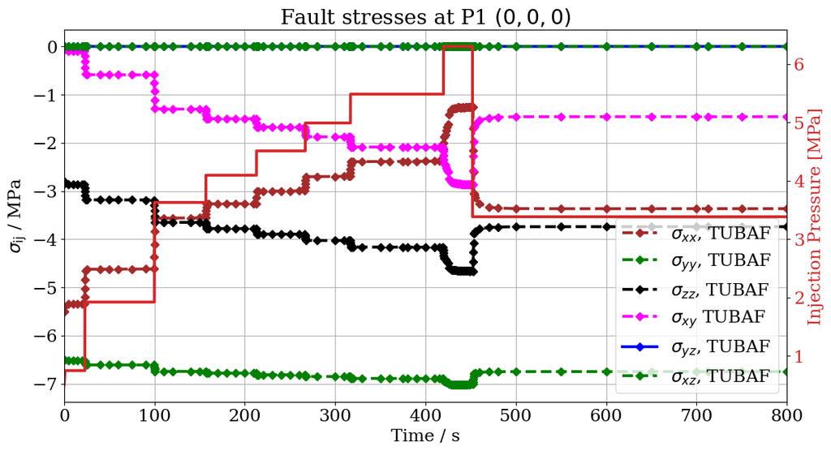

```python
fig, ax1 = plt.subplots(figsize=(13.5, 7))
ax1.plot(
    timeSteps,
    sig00[1:] * 1e-6,
    label="$\\sigma_{xx}$, TUBAF",
    color="brown",
    ls="--",
    marker="D",
)
ax1.plot(
    timeSteps,
    sig11[1:] * 1e-6,
    label="$\\sigma_{yy}$, TUBAF",
    color="green",
    ls="--",
    marker="D",
)
ax1.plot(
    timeSteps,
    sig22[1:] * 1e-6,
    label="$\\sigma_{zz}$, TUBAF",
    color="black",
    ls="--",
    marker="D",
)
ax1.plot(
    timeSteps,
    sig01[1:] * 1e-6,
    label="$\\sigma_{xy}$ TUBAF",
    color="magenta",
    ls="--",
    marker="D",
)
ax1.plot(
    timeSteps,
    sig12[1:] * 1e-6,
    label="$\\sigma_{yz}$, TUBAF",
    color="blue",
    ls="-",
    marker="D",
)
ax1.plot(
    timeSteps,
    sig02[1:] * 1e-6,
    label="$\\sigma_{xz}$, TUBAF",
    color="green",
    ls="--",
    marker="D",
)
ax1.set_ylabel("$\\sigma_{\\mathrm{ij}}$ / MPa")
ax1.set_xlabel("Time / s")
ax1.set_title("Fault stresses at P1 $(0, 0, 0)$")
ax1.legend()
ax1.grid(True)
# Create a second y-axis for the second data series
ax2 = ax1.twinx()
color = "tab:red"
ax2.set_ylabel("Injection Pressure [MPa]", color=color)  # For the second data series
ax2.plot(injectionPressure[0], injectionPressure[4] / 1e6, color=color)
ax2.tick_params(axis="y", labelcolor=color)
ax2.set_xlim([0, 800])
# Set x-axis limits
```

```
(0.0, 800.0)
```

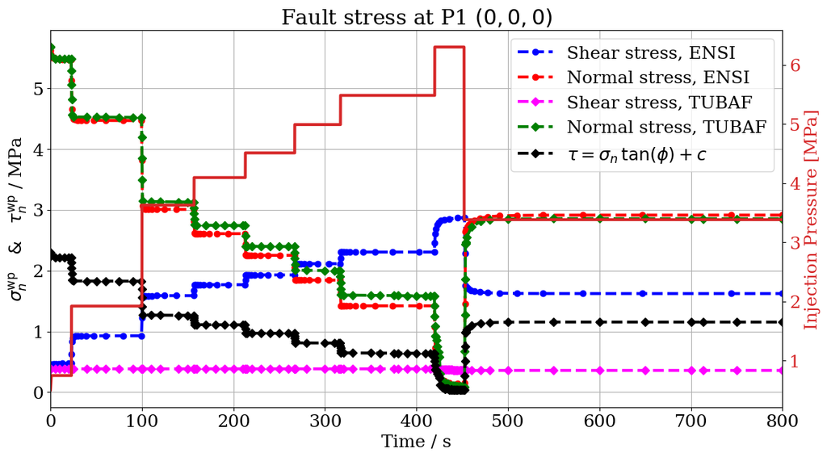

```python
fig, ax1 = plt.subplots(figsize=(13.5, 7))
ax1.plot(
    FM1[1],
    FM1[17] * 1e-6,
    label="Shear stress, ENSI",
    color="blue",
    ls="--",
    marker="o",
)
ax1.plot(
    FM1[1],
    FM1[18] * 1e-6,
    label="Normal stress, ENSI",
    color="red",
    ls="--",
    marker="o",
)
ax1.plot(
    timeSteps,
    tau_wp[1:] * 1e-6,
    label="Shear stress, TUBAF",
    color="magenta",
    ls="--",
    marker="D",
)
ax1.plot(
    timeSteps,
    -sigma_wp[1:] * 1e-6,
    label="Normal stress, TUBAF",
    color="green",
    ls="--",
    marker="D",
)
ax1.plot(
    timeSteps,
    -sigma_wp[1:] * 1e-6 * math.tan(math.radians(22)),
    label="$\\tau = \\sigma_n\,\\tan(\phi) + c$",
    color="black",
    ls="--",
    marker="D",
)
ax1.set_ylabel("$\\sigma^{\\mathrm{wp}}_n  \quad & \quad \\tau^{\\mathrm{wp}}_n$ / MPa")
ax1.set_xlabel("Time / s")
ax1.set_title("Fault stress at P1 $(0, 0, 0)$")
ax1.legend()
ax1.grid(True)

# Create a second y-axis for the second data series
ax2 = ax1.twinx()
color = "tab:red"
ax2.set_ylabel("Injection Pressure [MPa]", color=color)  # For the second data series
ax2.plot(injectionPressure[0], injectionPressure[4] / 1e6, color=color)
ax2.tick_params(axis="y", labelcolor=color)
ax2.set_xlim([0, 800])
```

## Fault stress at P3: $(0, -0.63, -1.36)$

```python
theta = 155.0
pt = "pt2"
csv_file = "stress_results.csv"
file = results["stress"]
sig01, sig02, sig12, sig00, sig11, sig22, sigma_wp, tau_wp = stress_ns(csv_file, file, pt, theta)
```

[output not shown]

```
(0.0, 800.0)
```

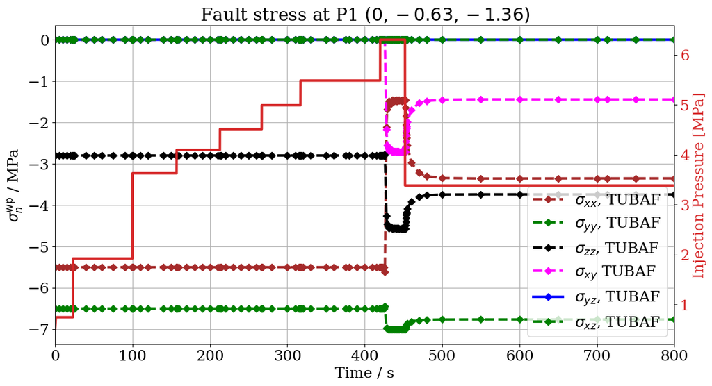

```python
fig, ax1 = plt.subplots(figsize=(13.5, 7))
ax1.plot(
    timeSteps,
    sig00[1:] * 1e-6,
    label="$\\sigma_{xx}$, TUBAF",
    color="brown",
    ls="--",
    marker="D",
)
ax1.plot(
    timeSteps,
    sig11[1:] * 1e-6,
    label="$\\sigma_{yy}$, TUBAF",
    color="green",
    ls="--",
    marker="D",
)
ax1.plot(
    timeSteps,
    sig22[1:] * 1e-6,
    label="$\\sigma_{zz}$, TUBAF",
    color="black",
    ls="--",
    marker="D",
)
ax1.plot(
    timeSteps,
    sig01[1:] * 1e-6,
    label="$\\sigma_{xy}$ TUBAF",
    color="magenta",
    ls="--",
    marker="D",
)
ax1.plot(
    timeSteps,
    sig12[1:] * 1e-6,
    label="$\\sigma_{yz}$, TUBAF",
    color="blue",
    ls="-",
    marker="D",
)
ax1.plot(
    timeSteps,
    sig02[1:] * 1e-6,
    label="$\\sigma_{xz}$, TUBAF",
    color="green",
    ls="--",
    marker="D",
)
ax1.set_ylabel("$\\sigma^{\\mathrm{wp}}_n$ / MPa")
ax1.set_xlabel("Time / s")
ax1.set_title("Fault stress at P1 $(0, -0.63, -1.36)$")
ax1.legend()
ax1.grid(True)

# Create a second y-axis for the second data series
ax2 = ax1.twinx()
color = "tab:red"
ax2.set_ylabel("Injection Pressure [MPa]", color=color)  # For the second data series
ax2.plot(injectionPressure[0], injectionPressure[4] / 1e6, color=color)
ax2.tick_params(axis="y", labelcolor=color)
ax2.set_xlim([0, 800])
# Set x-axis limits
```

```
(0.0, 800.0)
```

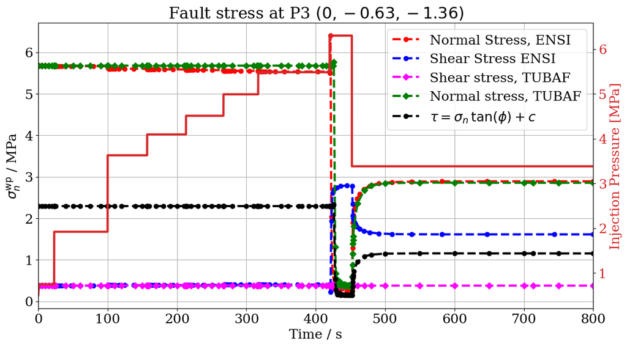

```python
fig, ax1 = plt.subplots(figsize=(13.5, 7))
ax1.plot(
    FM1[1],
    FM1[22] * 1e-6,
    label="Normal Stress, ENSI",
    color="red",
    ls="--",
    marker="o",
)  # Line plot with markers
ax1.plot(
    FM1[1], FM1[21] * 1e-6, label="Shear Stress ENSI", color="blue", ls="--", marker="o"
)  # Line plot with markers
ax1.plot(
    timeSteps,
    #-sig01[1:] * 1e-6,
    tau_wp[1:] * 1e-6,
    label="Shear stress, TUBAF",
    color="magenta",
    ls="--",
    marker="D",
)
ax1.plot(
    timeSteps,
    -sigma_wp[1:] * 1e-6,
    label="Normal stress, TUBAF",
    color="green",
    ls="--",
    marker="D",
)
ax1.plot(
    timeSteps,
    -sigma_wp[1:] * 1e-6 * math.tan(math.radians(22)),
    label="$\\tau = \\sigma_n\,\\tan(\phi) + c$",
    color="black",
    ls="--",
    marker="o",
)
ax1.set_ylabel("$\\sigma^{\\mathrm{wp}}_n$ / MPa")
ax1.set_xlabel("Time / s")
ax1.set_title("Fault stress at P3 $(0, -0.63, -1.36)$")
ax1.legend()
ax1.grid(True)

# Create a second y-axis for the second data series
ax2 = ax1.twinx()
color = "tab:red"
ax2.set_ylabel("Injection Pressure [MPa]", color=color)  # For the second data series
ax2.plot(injectionPressure[0], injectionPressure[4] / 1e6, color=color)
ax2.tick_params(axis="y", labelcolor=color)
ax2.set_xlim([0, 800])
# Set x-axis limits
```

```python
theta = 155.0
pt = "pt2"
csv_file = "stress_results.csv"
file = results["stress"]
sig01, sig02, sig12, sig00, sig11, sig22, sigma_wp, tau_wp = stress_ns(csv_file, file, pt, theta)
```

```
(0.0, 800.0)
```

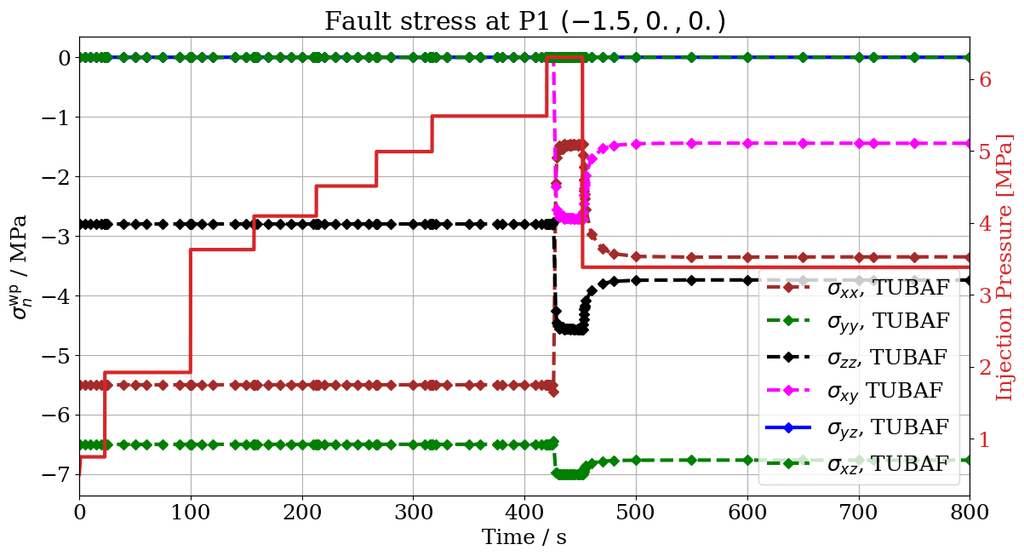

```python
fig, ax1 = plt.subplots(figsize=(13.5, 7))
ax1.plot(
    timeSteps,
    sig00[1:] * 1e-6,
    label="$\\sigma_{xx}$, TUBAF",
    color="brown",
    ls="--",
    marker="D",
)
ax1.plot(
    timeSteps,
    sig11[1:] * 1e-6,
    label="$\\sigma_{yy}$, TUBAF",
    color="green",
    ls="--",
    marker="D",
)
ax1.plot(
    timeSteps,
    sig22[1:] * 1e-6,
    label="$\\sigma_{zz}$, TUBAF",
    color="black",
    ls="--",
    marker="D",
)
ax1.plot(
    timeSteps,
    sig01[1:] * 1e-6,
    label="$\\sigma_{xy}$ TUBAF",
    color="magenta",
    ls="--",
    marker="D",
)
ax1.plot(
    timeSteps,
    sig12[1:] * 1e-6,
    label="$\\sigma_{yz}$, TUBAF",
    color="blue",
    ls="-",
    marker="D",
)
ax1.plot(
    timeSteps,
    sig02[1:] * 1e-6,
    label="$\\sigma_{xz}$, TUBAF",
    color="green",
    ls="--",
    marker="D",
)
ax1.set_ylabel("$\\sigma^{\\mathrm{wp}}_n$ / MPa")
ax1.set_xlabel("Time / s")
ax1.set_title("Fault stress at P1 $(-1.5, 0., 0.)$")
ax1.legend()
ax1.grid(True)

# Create a second y-axis for the second data series
ax2 = ax1.twinx()
color = "tab:red"
ax2.set_ylabel("Injection Pressure [MPa]", color=color)  # For the second data series
ax2.plot(injectionPressure[0], injectionPressure[4] / 1e6, color=color)
ax2.tick_params(axis="y", labelcolor=color)
ax2.set_xlim([0, 800])
# Set x-axis limits
```

```
(0.0, 800.0)
```

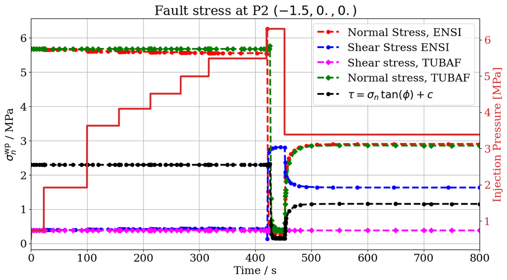

```python
fig, ax1 = plt.subplots(figsize=(13.5, 7))
ax1.plot(
    FM1[1],
    FM1[20] * 1e-6,
    label="Normal Stress, ENSI",
    color="red",
    ls="--",
    marker="o",
)  # Line plot with markers
ax1.plot(
    FM1[1], FM1[19] * 1e-6, label="Shear Stress ENSI", color="blue", ls="--", marker="o"
)  # Line plot with markers
ax1.plot(
    timeSteps,
    tau_wp[1:] * 1e-6,
    label="Shear stress, TUBAF",
    color="magenta",
    ls="--",
    marker="D",
)
ax1.plot(
    timeSteps,
    -sigma_wp[1:] * 1e-6,
    label="Normal stress, TUBAF",
    color="green",
    ls="--",
    marker="D",
)
ax1.plot(
    timeSteps,
    -sigma_wp[1:] * 1e-6 * math.tan(math.radians(22)),
    label="$\\tau=\\sigma_n\,\\tan(\phi) + c $",
    color="black",
    ls="--",
    marker="o",
)
ax1.set_ylabel("$\\sigma^{\\mathrm{wp}}_n$ / MPa")
ax1.set_xlabel("Time / s")
ax1.set_title("Fault stress at P2 $(-1.5, 0., 0.)$")
ax1.legend()
ax1.grid(True)

# Create a second y-axis for the second data series
ax2 = ax1.twinx()
color = "tab:red"
ax2.set_ylabel("Injection Pressure [MPa]", color=color)  # For the second data series
ax2.plot(injectionPressure[0], injectionPressure[4] / 1e6, color=color)
ax2.tick_params(axis="y", labelcolor=color)
ax2.set_xlim([0, 800])
# Set x-axis limits
```

## Dispalcement jumps between two points (M and N) located on the left and right hand side of the fault along a line prependicular to the fault

```python
def displacement_jump(file, thetap, thetam):
    u_np = file["displacement"]["pt4"].T[0] * math.cos(math.radians(thetap)) + file[
        "displacement"
    ]["pt4"].T[1] * math.sin(math.radians(thetap))

    u_nm = file["displacement"]["pt5"].T[0] * math.cos(math.radians(thetam)) + file[
        "displacement"
    ]["pt5"].T[1] * math.sin(math.radians(thetam))

    u_sp = -file["displacement"]["pt4"].T[0] * math.sin(math.radians(thetap)) + file[
        "displacement"
    ]["pt4"].T[1] * math.cos(math.radians(thetap))

    u_sm = -file["displacement"]["pt5"].T[0] * math.sin(math.radians(thetam)) + file[
        "displacement"
    ]["pt5"].T[1] * math.cos(math.radians(thetam))
    return -u_np, u_nm, -u_sp, u_sm
```

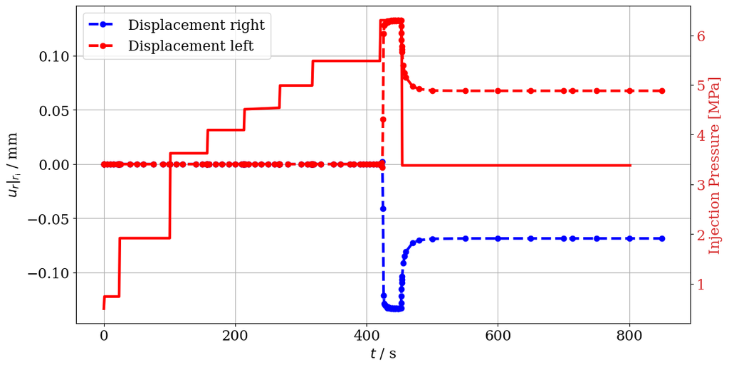

```python
fig, ax1 = plt.subplots(figsize=(12.5, 6.5))
thetap = 155.0
thetam = -25
u_np, u_nm, u_sp, u_sm = displacement_jump(results, thetap, thetam)

ax1.plot(
    timeSteps,
    u_np* 1000.0,
    label="Displacement right",
    ls="--",
    color="blue",
    marker="o",
)
ax1.plot(
    timeSteps,
    u_nm * 1000.0,
    label="Displacement left",
    ls="--",
    color="red",
    marker="o",
)
ax1.set_xlabel("$t$ / s")
ax1.grid(True)
ax1.set_ylabel("$u_r|_{r_\\mathrm{i}}$ / mm")
ax1.legend(loc="upper left")

# Create a second y-axis for the second data series
ax2 = ax1.twinx()
color = "tab:red"
ax2.plot(
    dt.cumsum()[1:] - dt[1],
    p[1:],
    label="Injected pressure pressure in MPa",
    color="red",
)
ax2.set_xlabel("$t-t_\\mathrm{ic}$ / s")
ax2.set_ylabel("Injection Pressure [MPa]", color=color)  # For the second data series
ax2.tick_params(axis="y", labelcolor=color)
```

## Evolution of permeability $(k_{\text{d}})$ along fault dip

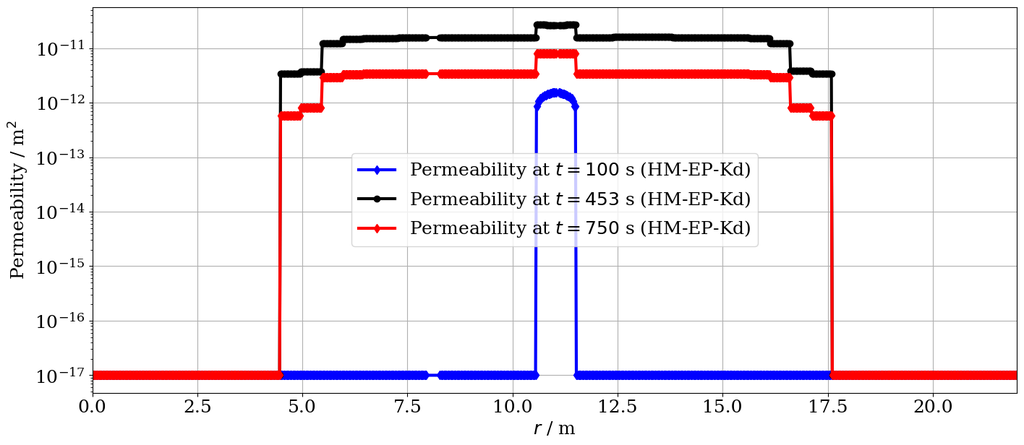

```python
Time = [100, 453, 750]
colors = ["blue", "black", "red", "magenta"]
markers = ["d", "o"]
fig, ax = plt.subplots(figsize=(14.5, 6.5))

# Plotting loop
for k, i in enumerate(Time):
    # Read permeability data
    permeability_data = pvdfile_elastop_Kd_FM1.read_set_data(
        i, "permeability", pointsetarray=fpoints_mid
    ).T[0]
    # Filter out zero values
    filtered_indices = permeability_data != 0
    filtered_rad = rad[filtered_indices]
    filtered_permeability = permeability_data[filtered_indices]

    # Plot filtered data
    ax.plot(
        filtered_rad,
        filtered_permeability,
        label=f"Permeability at $t = {i}$ s (HM-EP-Kd)",
        color=colors[k % len(colors)],  # Cycle through colors if needed
        ls="-",
        marker=markers[k % len(markers)],  # Cycle through markers if needed
    )

# Customizations
ax.set(
    xlabel="$r$ / m",
    ylabel="Permeability / m$^\mathrm{2}$",
    xlim=(0.0, 22.0),
)
plt.yscale("log")  # Logarithmic y-axis
ax.legend()
ax.grid(True)
fig.tight_layout()

# Show the plot
plt.show()
```

## Evolution of weak plane equivalent plastic strain along fault dip

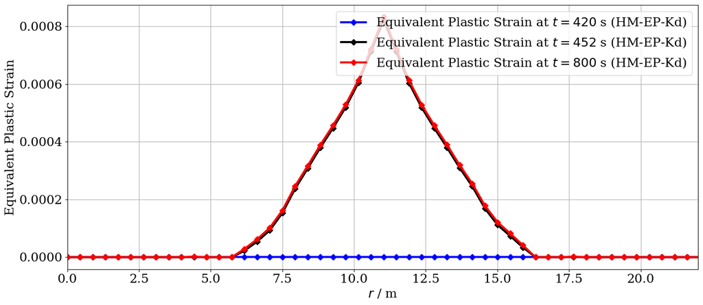

```python
Time = [420, 452, 800]
k = 0
fig, ax = plt.subplots(figsize=(14.5, 6.5))
threshold = 1e-16
for i in Time:
    colors = ["blue", "black", "red", "magenta"]
    markers = ["d", "o"]
    peeq = pvdfile_elastop_Kd_FM1.read_set_data(
        i, "EquivalentPlasticStrainWeakPlane", pointsetarray=fpoints_mid
    )
    peeq_data = peeq.copy()
    peeq_data[peeq <= threshold] = 0.0
    ax.plot(
        rad[::20],
        peeq_data[::20],
        label="Equivalent Plastic Strain at $t = %i$ s (HM-EP-Kd)" % i,
        color=colors[k],
        ls="-",
        marker="D",
    )
    k += 1
ax.set(xlim=(0.0, 22.0), autoscale_on=True)
ax.set_xlabel("$r$ / m")
ax.set_ylabel("Equivalent Plastic Strain")
ax.legend()
ax.grid(True)
fig.tight_layout()
```

# References

[1] Rutqvist, J., Graupner, B., Guglielmi, Y., Kim, T., Maßmann, J., Nguyen, T.S., Park, J.W., Shiu, W., Urpi, L., Yoon, J.S. and Ziefle, G., 2020. An international model comparison study of controlled fault activation experiments in argillaceous claystone at the Mont Terri Laboratory. *International Journal of Rock Mechanics and Mining Sciences*, 136, p.104505.

[2] Seyedi, D.M., Plúa, C., Vitel, M., Armand, G., Rutqvist, J., Birkholzer, J., Xu, H., Guo, R., Thatcher, K.E., Bond, A.E. and Wang, W., 2021. Upscaling THM modeling from small-scale to full-scale in-situ experiments in the Callovo-Oxfordian claystone. *International Journal of Rock Mechanics and Mining Sciences*, 144, p.104582.

[3] Ghabezloo, S. and Sulem, J., 2009. Stress dependent thermal pressurization of a fluid-saturated rock. *Rock Mechanics and Rock Engineering*, 42, pp.1-24.

[4] Rutqvist, J., Zheng, L., Chen, F., Liu, H. H., & Birkholzer, J. (2014). Modeling of coupled thermo-hydro-mechanical processes with links to geochemistry associated with bentonite-backfilled repository tunnels in clay formations. *Rock Mechanics and Rock Engineering*, 47, 167-186.

[5] Davies, R., Foulger, G., Bindley, A. and Styles, P., 2013. Induced seismicity and hydraulic fracturing for the recovery of hydrocarbons. *Marine and petroleum geology*, 45, pp.171-185.

[6] Flewelling, S.A., Tymchak, M.P. and Warpinski, N., 2013. Hydraulic fracture height limits and fault interactions in tight oil and gas formations. *Geophysical Research Letters*, 40(14), pp.3602-3606.

[7] Lei, X., Huang, D., Su, J., Jiang, G., Wang, X., Wang, H., Guo, X. and Fu, H., 2017. Fault reactivation and earthquakes with magnitudes of up to Mw4.7 induced by shale-gas hydraulic fracturing in Sichuan Basin, China. *Scientific reports*, 7(1), p.7971.

[8] Zill, F., Lüdeling, C., Kolditz, O., & Nagel, T. (2021). Hydro-mechanical continuum modelling of fluid percolation through rock salt. *International Journal of Rock Mechanics and Mining Sciences, 147, 104879*.

[9] Urpi, L., Graupner, B., Wang, W., Nagel, T., & Rinaldi, A. P. (2020). Hydro-mechanical fault reactivation modeling based on elasto-plasticity with embedded weakness planes. *Journal of Rock Mechanics and Geotechnical Engineering*, 12(4), 877-885.

[10] Corkum, A.G. and Martin, C.D., 2007. Modelling a mine-by test at the Mont Terri rock laboratory, Switzerland. International Journal of Rock Mechanics and Mining Sciences, 44(6), pp.846-859.

[11] Guglielmi, Y., Elsworth, D., Cappa, F., Henry, P., Gout, C., Dick, P., & Durand, J. (2015). In situ observations on the coupling between hydraulic diffusivity and displacements during fault reactivation in shales. *Journal of Geophysical Research*: Solid Earth, 120(11), 7729-7748.

[12] Singh, B. (1973, July). Continuum characterization of jointed rock masses: Part I—The constitutive equations. In International Journal of Rock Mechanics and Mining Sciences & Geomechanics Abstracts (Vol. 10, No. 4, pp. 311-335). Pergamon.